# various_analyses

# 1 Load and get the datasets ready

# 2 Compare arrangements for their difficulty in phase 1

## 2.1 Replot all the arrangements in phase 1

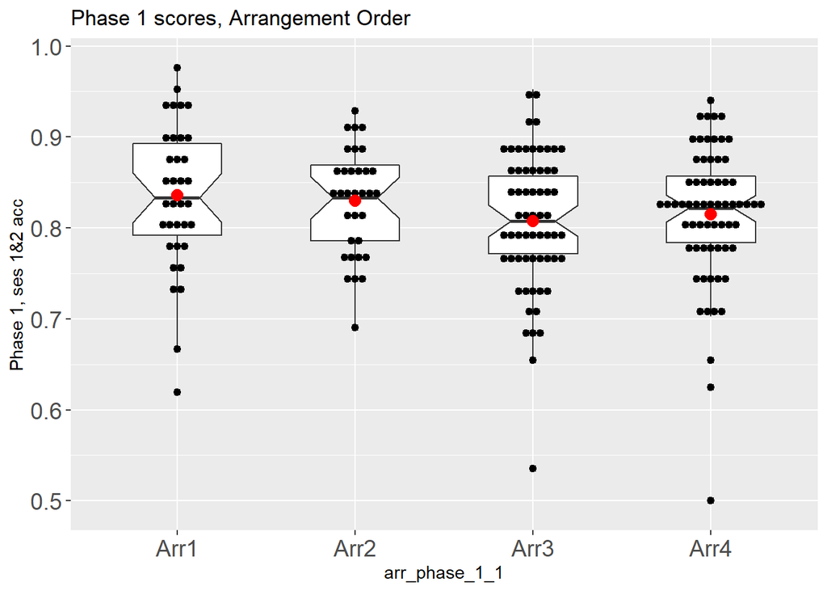

| arr_phase_1_1 | variable | n | mean | sd |
| --- | --- | --- | --- | --- |
| 1 | phase_1_ses_1_2_perf | 35 | 0.836 | 0.080 |
| 14 | phase_1_ses_1_2_perf | 33 | 0.830 | 0.058 |
| 3 | phase_1_ses_1_2_perf | 62 | 0.807 | 0.076 |
| 15 | phase_1_ses_1_2_perf | 65 | 0.815 | 0.076 |

## 2.2 Compare arr3 and arr4 for phase 1, are they reliably different?

I perform an equivalence test which will simultaneously test (a) whether the effect is significantly different from zero and (b) whether its statistically equivalent to some range of minimally interesting effect sizes.

I’m not exactly sure what the maximum difference should be between phase 1 arr3 and arr4 scores, such that it would not be a problem.

Think how many more correct responses for arr3 vs arr4 we would consider to be a problem? We are calculating performance over 2 sessions for each phase, that is 82 trials total. Lets say arr2 vs arr4 differ by 4 correct responses in phase 1, that is 4*100/82=4.878% difference in accuracy. So, if our data show that arr3 vs arr4 differ by an amount that is statistically lower than 4.878, then we’d be happy.

Another approach for determining the maximum allowed difference would be to look at how much do people improve from phase 1 to phase 2 in the congruent case, how many more toys to they correctly respond do. Phase 2 must surely be better than phase 1 for congruent case, so people’s improvements there will tell us the ballpark range for expected difference between an “easy” and “harder” arrangements. Below, you can see a table for each subcondition (but only congruent) with summary statistics for phase2 - phase1 scores.

Minimal difference we see is 0.02 so 2% difference, for subcondition neck_legs_space & arrangement 4. That suggests 1-2 toy difference between phases, thats very low…

| concept_phase_1 | arr_phase_1_1 | variable | n | mean | sd |
| --- | --- | --- | --- | --- | --- |
| beak_tail_space | 1 | phase_2_min_phase_1_ses_1_2_perf | 8 | 0.103 | 0.067 |
| beak_tail_space | 14 | phase_2_min_phase_1_ses_1_2_perf | 8 | 0.068 | 0.093 |
| beak_tail_space | 3 | phase_2_min_phase_1_ses_1_2_perf | 15 | 0.055 | 0.074 |
| beak_tail_space | 15 | phase_2_min_phase_1_ses_1_2_perf | 16 | 0.073 | 0.072 |
| neck_legs_space | 1 | phase_2_min_phase_1_ses_1_2_perf | 8 | 0.057 | 0.061 |
| neck_legs_space | 14 | phase_2_min_phase_1_ses_1_2_perf | 8 | 0.066 | 0.065 |
| neck_legs_space | 3 | phase_2_min_phase_1_ses_1_2_perf | 15 | 0.021 | 0.080 |
| neck_legs_space | 15 | phase_2_min_phase_1_ses_1_2_perf | 16 | 0.020 | 0.085 |

So for the equivalence test, I entered boundaries of 0.26 standardized difference in scores, which corresponds roughly to 0.02 raw difference in scores.

Results show that the data is not significantly different from 0. However, the 95% confidence interval makes it clear that its consistent with a wide-range of effect sizes. So we cannot make a confident conclusion that arr3 and arr4 are not different in phase 1…

```
## TOST results:
## t-value lower bound: 0.929   p-value lower bound: 0.177
## t-value upper bound: -2.00   p-value upper bound: 0.024
## degrees of freedom : 124.8
##
## Equivalence bounds (Cohen's d):
## low eqbound: -0.26
## high eqbound: 0.26
##
## Equivalence bounds (raw scores):
## low eqbound: -0.0197
## high eqbound: 0.0197
##
## TOST confidence interval:
## lower bound 90% CI: -0.03
## upper bound 90% CI:  0.015
##
## NHST confidence interval:
## lower bound 95% CI: -0.034
## upper bound 95% CI:  0.019
##
## Equivalence Test Result:
## The equivalence test was non-significant, t(124.8) = 0.929, p = 0.177, given equivalence bounds of -0.0197 and 0.0197 (on a raw scale) and an alpha of 0.05.
```

```
##
## Null Hypothesis Test Result:
## The null hypothesis test was non-significant, t(124.8) = -0.535, p = 0.593, given an alpha of 0.05.
```

```
##
## Based on the equivalence test and the null-hypothesis test combined, we can conclude that the observed effect is statistically not different from zero and statistically not equivalent to zero.
```

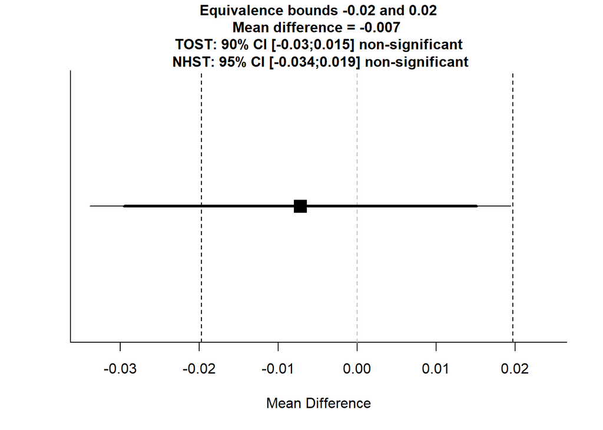

## 2.3 Compare arr1 and arr2 for phase 1, are they different?

```
## TOST results:
## t-value lower bound: 1.52    p-value lower bound: 0.066
## t-value upper bound: -0.795  p-value upper bound: 0.215
## degrees of freedom : 62.17
##
## Equivalence bounds (Cohen's d):
## low eqbound: -0.28
## high eqbound: 0.28
##
## Equivalence bounds (raw scores):
## low eqbound: -0.0196
## high eqbound: 0.0196
##
## TOST confidence interval:
## lower bound 90% CI: -0.022
## upper bound 90% CI:  0.034
##
## NHST confidence interval:
## lower bound 95% CI: -0.028
## upper bound 95% CI:  0.04
##
## Equivalence Test Result:
## The equivalence test was non-significant, t(62.17) = -0.795, p = 0.215, given equivalence bounds of -0.0196 and 0.0196 (on a raw scale) and an alpha of 0.05.
```

```
##
## Null Hypothesis Test Result:
## The null hypothesis test was non-significant, t(62.17) = 0.364, p = 0.717, given an alpha of 0.05.
```

```
##
## Based on the equivalence test and the null-hypothesis test combined, we can conclude that the observed effect is statistically not different from zero and statistically not equivalent to zero.
```

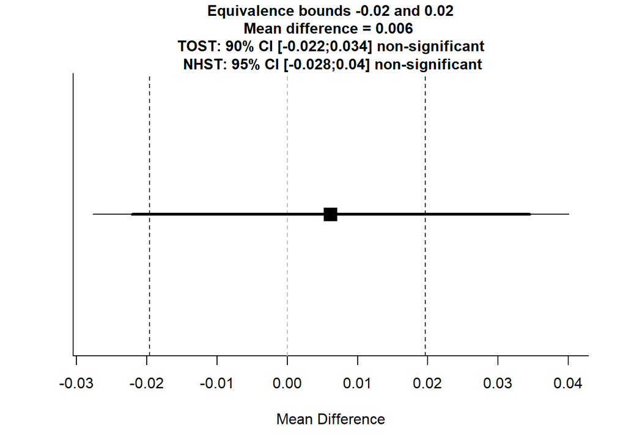

# 3 Frequentist ANOVA analysis

## 3.1 What if no-outlier always in phase2? Or if outlier always in phase 2?

### 3.1.1 Separately for each phase

```
## notch went outside hinges. Try setting notch=FALSE.
## notch went outside hinges. Try setting notch=FALSE.
## notch went outside hinges. Try setting notch=FALSE.
## notch went outside hinges. Try setting notch=FALSE.
```

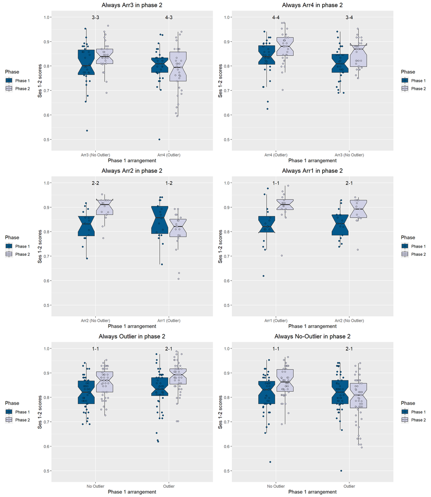

### 3.1.2 P2-P1 scores:

```
## notch went outside hinges. Try setting notch=FALSE.
## notch went outside hinges. Try setting notch=FALSE.
## notch went outside hinges. Try setting notch=FALSE.
```

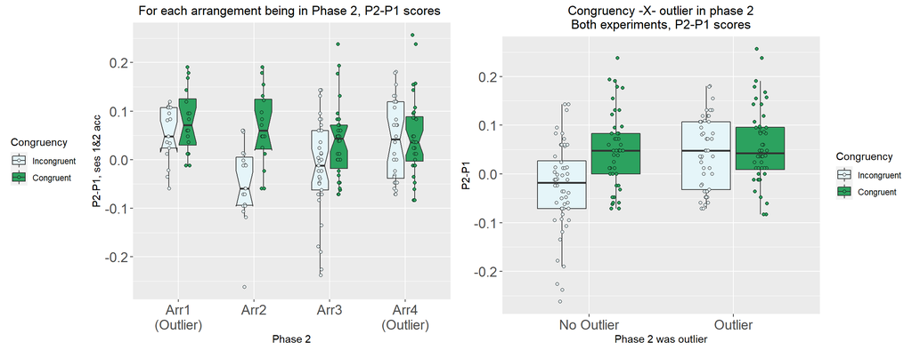

```
## Coefficient covariances computed by hccm()
```

Table 3.1: Full ANOVA, with factors: Experiment, congruency, concept in P2, outlier in P2

Effect

DFn

DFd

F

p

p<.05

ges

congruency

1

179

15.3760000

0.000125

7.90e-02

concept_phase_2

1

179

15.8250000

0.000101

8.10e-02

phase_2_lower_left_outlier

1

179

12.9730000

0.000409

6.80e-02

arrangement_pairs

1

179

0.7770000

0.379000

4.00e-03

congruency:concept_phase_2

1

179

0.4590000

0.499000

3.00e-03

congruency:phase_2_lower_left_outlier

1

179

6.8210000

0.010000

3.70e-02

concept_phase_2:phase_2_lower_left_outlier

1

179

0.0000239

0.996000

1.00e-07

congruency:arrangement_pairs

1

179

2.7720000

0.098000

1.50e-02

concept_phase_2:arrangement_pairs

1

179

0.3070000

0.580000

2.00e-03

phase_2_lower_left_outlier:arrangement_pairs

1

179

1.1660000

0.282000

6.00e-03

congruency:concept_phase_2:phase_2_lower_left_outlier

1

179

1.4230000

0.234000

8.00e-03

congruency:concept_phase_2:arrangement_pairs

1

179

0.0690000

0.792000

3.88e-04

congruency:phase_2_lower_left_outlier:arrangement_pairs

1

179

0.7390000

0.391000

4.00e-03

concept_phase_2:phase_2_lower_left_outlier:arrangement_pairs

1

179

0.6680000

0.415000

4.00e-03

congruency:concept_phase_2:phase_2_lower_left_outlier:arrangement_pairs

1

179

0.0760000

0.782000

4.27e-04

```
## Coefficient covariances computed by hccm()
```

Table 3.1: Expt1: congruency -X- concept -X- outlier

Effect

DFn

DFd

F

p

p<.05

ges

congruency

1

60

17.510

9.47e-05

0.226

concept_phase_2

1

60

4.729

3.40e-02

0.073

phase_2_lower_left_outlier

1

60

11.885

1.00e-03

0.165

congruency:concept_phase_2

1

60

0.511

4.77e-01

0.008

congruency:phase_2_lower_left_outlier

1

60

6.453

1.40e-02

0.097

concept_phase_2:phase_2_lower_left_outlier

1

60

0.531

4.69e-01

0.009

congruency:concept_phase_2:phase_2_lower_left_outlier

1

60

0.298

5.87e-01

0.005

```
## Coefficient covariances computed by hccm()
```

Table 3.1: Expt2: congruency -X- concept -X- outlier

Effect

DFn

DFd

F

p

p<.05

ges

congruency

1

119

4.207

0.042

0.034

concept_phase_2

1

119

11.182

0.001

0.086

phase_2_lower_left_outlier

1

119

4.515

0.036

0.037

congruency:concept_phase_2

1

119

0.129

0.720

0.001

congruency:phase_2_lower_left_outlier

1

119

2.300

0.132

0.019

concept_phase_2:phase_2_lower_left_outlier

1

119

0.203

0.653

0.002

congruency:concept_phase_2:phase_2_lower_left_outlier

1

119

1.140

0.288

0.009

### 3.1.3 Just Phase 2 scores:

```
## notch went outside hinges. Try setting notch=FALSE.
## notch went outside hinges. Try setting notch=FALSE.
```

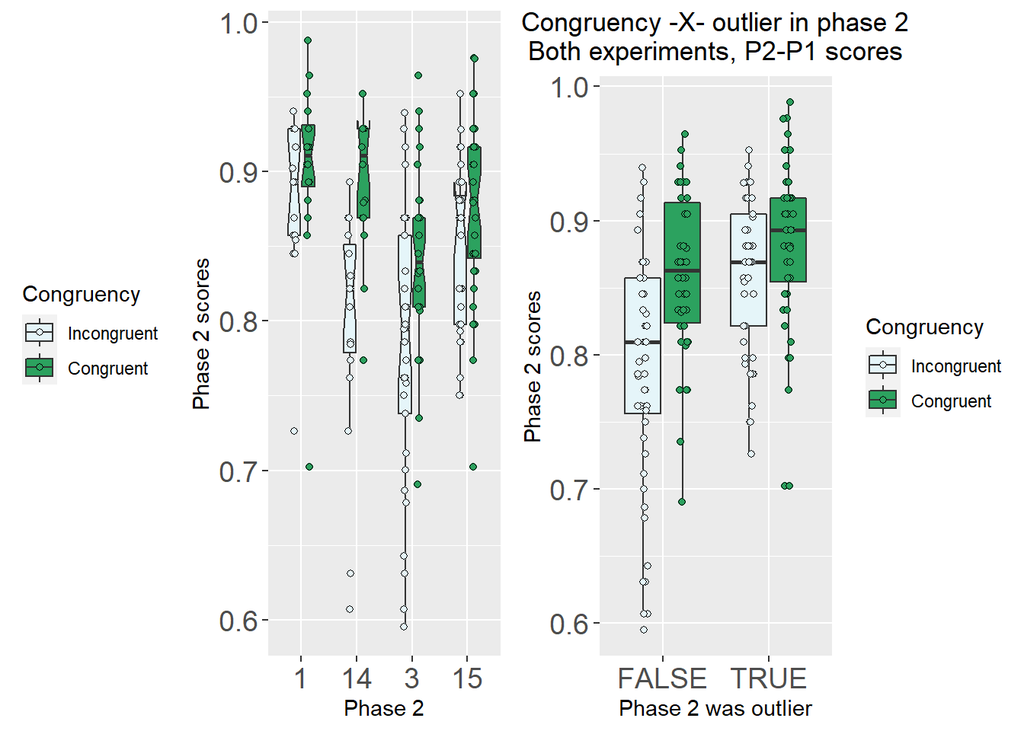

```
## Coefficient covariances computed by hccm()
```

Table 3.2: Congruency -X- Phase 2 outlier -X- Experiment

Effect

DFn

DFd

F

p

p<.05

ges

congruency

1

179

25.1690000

1.30e-06

1.23e-01

phase_2_lower_left_outlier

1

179

27.1790000

5.00e-07

1.32e-01

concept_phase_2

1

179

14.2570000

2.17e-04

7.40e-02

arrangement_pairs

1

179

11.2730000

9.60e-04

5.90e-02

congruency:phase_2_lower_left_outlier

1

179

6.1000000

1.40e-02

3.30e-02

congruency:concept_phase_2

1

179

3.8050000

5.30e-02

2.10e-02

phase_2_lower_left_outlier:concept_phase_2

1

179

0.0490000

8.25e-01

2.74e-04

congruency:arrangement_pairs

1

179

0.3760000

5.41e-01

2.00e-03

phase_2_lower_left_outlier:arrangement_pairs

1

179

0.0000836

9.93e-01

5.00e-07

concept_phase_2:arrangement_pairs

1

179

0.1590000

6.90e-01

8.90e-04

congruency:phase_2_lower_left_outlier:concept_phase_2

1

179

2.7840000

9.70e-02

1.50e-02

congruency:phase_2_lower_left_outlier:arrangement_pairs

1

179

1.3090000

2.54e-01

7.00e-03

congruency:concept_phase_2:arrangement_pairs

1

179

0.0430000

8.35e-01

2.43e-04

phase_2_lower_left_outlier:concept_phase_2:arrangement_pairs

1

179

0.0290000

8.66e-01

1.60e-04

congruency:phase_2_lower_left_outlier:concept_phase_2:arrangement_pairs

1

179

0.7350000

3.92e-01

4.00e-03

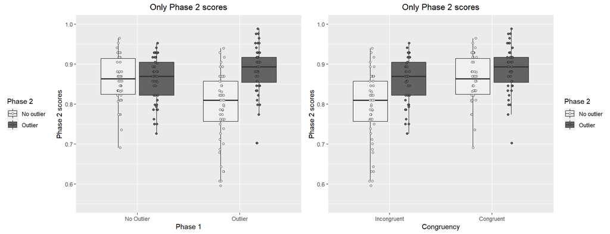

```
## Coefficient covariances computed by hccm()
```

Table 3.3: Phase 1 outlier -X- Phase 2 outlier -X- Experiment

Effect

DFn

DFd

F

p

p<.05

ges

phase_1_lower_left_outlier

1

187

6.200

1.40e-02

3.20e-02

phase_2_lower_left_outlier

1

187

26.371

7.00e-07

1.24e-01

arrangement_pairs

1

187

10.532

1.00e-03

5.30e-02

phase_1_lower_left_outlier:phase_2_lower_left_outlier

1

187

24.022

2.10e-06

1.14e-01

phase_1_lower_left_outlier:arrangement_pairs

1

187

1.110

2.94e-01

6.00e-03

phase_2_lower_left_outlier:arrangement_pairs

1

187

0.012

9.14e-01

6.25e-05

phase_1_lower_left_outlier:phase_2_lower_left_outlier:arrangement_pairs

1

187

0.320

5.73e-01

2.00e-03

```
## Coefficient covariances computed by hccm()
```

Table 3.3: Congruency -X- Phase 2 outlier -X- Experiment

Effect

DFn

DFd

F

p

p<.05

ges

congruency

1

187

24.281

1.80e-06

1.15e-01

phase_2_lower_left_outlier

1

187

26.213

8.00e-07

1.23e-01

arrangement_pairs

1

187

10.532

1.00e-03

5.30e-02

congruency:phase_2_lower_left_outlier

1

187

6.072

1.50e-02

3.10e-02

congruency:arrangement_pairs

1

187

0.336

5.63e-01

2.00e-03

phase_2_lower_left_outlier:arrangement_pairs

1

187

0.006

9.40e-01

2.99e-05

congruency:phase_2_lower_left_outlier:arrangement_pairs

1

187

1.093

2.97e-01

6.00e-03